# R Notebook to predict Food Preference with SparklyR

**Predicting Food preferences with sparklyr (Machine Learning)**

*Shirin play ground*

Spark’s distributed machine learning library called *MLlib* sits on top of the spark core framework. With Sparklyr, you can easily access the MLlib.

```r
# Whether a preference for a country's cuisine can be predicted based on preference of other countries cuisines
library(sparklyr)
# install spark locally
spark_install(version = "2.0.0")
```

```
Spark 2.0.0 for Hadoop 2.7 or later already installed.
```

Now we can connect to a local spark instance

```r
sc=spark_connect(master = "local",version = "2.0.0")
```

```
Re-using existing Spark connection to local
```

Preparations for a custom ggplot theme

Load packages

```r
library(tidyr)
library(ggplot2)
library(dplyr)
library(ggrepel) # for non overlapping texy labels in plots
mytheme=function(base_size=12,base_family="sans"){
  theme_minimal(base_size = base_size,base_family = base_family)+
    theme(
      axis.text = element_text(size=12),
      axis.title = element_text(size=14),
      panel.grid.major = element_line(color="grey"),
      panel.grid.minor = element_blank(),
      panel.background = element_rect(fill = "aliceblue"),
      strip.background = element_rect(fill="lightgrey",color = "grey",size=1),
      strip.text = element_text(face="bold",size=12,color="black"),
      legend.position = "right",
      legend.justification = "top",
      panel.border = element_rect(color="grey",fill=NA,size = 0.85)
    )
}
```

all NA are recoded as 0

```r
# load the 538 library
library(fivethirtyeight)
head(food_world_cup)
```

| respondent_id | knowledge | interest | gender | age | household_income | education | location | algeria | argentina | australia | belgium | bosnia_and_herzegovina | brazil | cameroon | chile | china | colombia | costa_rica | croatia | cuba | ecuador | england | ethiopia | france | germany | ghana | greece | honduras | india | … |
| --- | --- | --- | --- | --- | --- | --- | --- | --- | --- | --- | --- | --- | --- | --- | --- | --- | --- | --- | --- | --- | --- | --- | --- | --- | --- | --- | --- | --- | --- | --- |
| 3308895255 | Intermediate | Some | Male | 18-29 | $100,000 - $149,999 | Less than high school degree | West South Central | N/A | 3 | 5 | 4 | N/A | 3 | N/A | 4 | 4 | N/A | 4 | N/A | N/A | N/A | 4 | 3 | 3 | 5 | N/A | N/A | N/A | 5 | … |
| 3308891308 | Novice | Some | Male | 18-29 | $100,000 - $149,999 | Some college or Associate degree | West South Central | N/A | N/A | 3 | 3 | N/A | 3 | N/A | N/A | 2 | N/A | N/A | N/A | N/A | N/A | 4 | N/A | 4 | 4 | N/A | 4 | N/A | 2 | … |
| 3308891135 | Intermediate | A lot | Male | 30-44 | $50,000 - $99,999 | Graduate degree | Pacific | 3 | 4 | N/A | 3 | N/A | 4 | 5 | 5 | 3 | 4 | 5 | 3 | 4 | 3 | 3 | 5 | 4 | 2 | 4 | 4 | 3 | 5 | … |
| 3308879091 | Novice | Not much | Male | 45-60 | $0 - $24,999 | Less than high school degree | New England | N/A | 3 | N/A | 3 | N/A | N/A | 3 | 3 | 4 | 2 | 4 | N/A | 4 | N/A | 3 | N/A | 3 | 3 | N/A | 4 | N/A | 3 | … |
| 3308871671 | Novice | Not much | Male | 30-44 | $25,000 - $49,999 | High school degree | Pacific | N/A | N/A | N/A | N/A | N/A | N/A | N/A | N/A | 3 | N/A | N/A | N/A | 3 | N/A | 2 | N/A | 3 | 3 | N/A | N/A | N/A | 3 | … |
| 3308871406 | Advanced | A lot | Female | 30-44 | $50,000 - $99,999 | Graduate degree | East North Central | N/A | 4 | 3 | 5 | 3 | 5 | N/A | 4 | 3 | 4 | 4 | 3 | 5 | 4 | 5 | N/A | 5 | 5 | N/A | 5 | N/A | 5 | … |

```r
food_world_cup[food_world_cup=="N/A"]=NA
food_world_cup[,9:48][is.na(food_world_cup[,9:48])]=0
food_world_cup$gender=as.factor(food_world_cup$gender)
food_world_cup$location=as.factor(food_world_cup$location)
```

We calculate the percentage for each preference category and plot them as a pie chart facetted by country

```r
# calculating percentages by country
head(food_world_cup)
```

| respondent_id | knowledge | interest | gender | age | household_income | education | location | algeria | argentina | australia | belgium | bosnia_and_herzegovina | brazil | cameroon | chile | china | colombia | costa_rica | croatia | cuba | ecuador | england | ethiopia | france | germany | ghana | greece | honduras | india | … |
| --- | --- | --- | --- | --- | --- | --- | --- | --- | --- | --- | --- | --- | --- | --- | --- | --- | --- | --- | --- | --- | --- | --- | --- | --- | --- | --- | --- | --- | --- | --- |
| 3308895255 | Intermediate | Some | Male | 18-29 | $100,000 - $149,999 | Less than high school degree | West South Central | 0 | 3 | 5 | 4 | 0 | 3 | 0 | 4 | 4 | 0 | 4 | 0 | 0 | 0 | 4 | 3 | 3 | 5 | 0 | 0 | 0 | 5 | … |
| 3308891308 | Novice | Some | Male | 18-29 | $100,000 - $149,999 | Some college or Associate degree | West South Central | 0 | 0 | 3 | 3 | 0 | 3 | 0 | 0 | 2 | 0 | 0 | 0 | 0 | 0 | 4 | 0 | 4 | 4 | 0 | 4 | 0 | 2 | … |
| 3308891135 | Intermediate | A lot | Male | 30-44 | $50,000 - $99,999 | Graduate degree | Pacific | 3 | 4 | 0 | 3 | 0 | 4 | 5 | 5 | 3 | 4 | 5 | 3 | 4 | 3 | 3 | 5 | 4 | 2 | 4 | 4 | 3 | 5 | … |
| 3308879091 | Novice | Not much | Male | 45-60 | $0 - $24,999 | Less than high school degree | New England | 0 | 3 | 0 | 3 | 0 | 0 | 3 | 3 | 4 | 2 | 4 | 0 | 4 | 0 | 3 | 0 | 3 | 3 | 0 | 4 | 0 | 3 | … |
| 3308871671 | Novice | Not much | Male | 30-44 | $25,000 - $49,999 | High school degree | Pacific | 0 | 0 | 0 | 0 | 0 | 0 | 0 | 0 | 3 | 0 | 0 | 0 | 3 | 0 | 2 | 0 | 3 | 3 | 0 | 0 | 0 | 3 | … |
| 3308871406 | Advanced | A lot | Female | 30-44 | $50,000 - $99,999 | Graduate degree | East North Central | 0 | 4 | 3 | 5 | 3 | 5 | 0 | 4 | 3 | 4 | 4 | 3 | 5 | 4 | 5 | 0 | 5 | 5 | 0 | 5 | 0 | 5 | … |

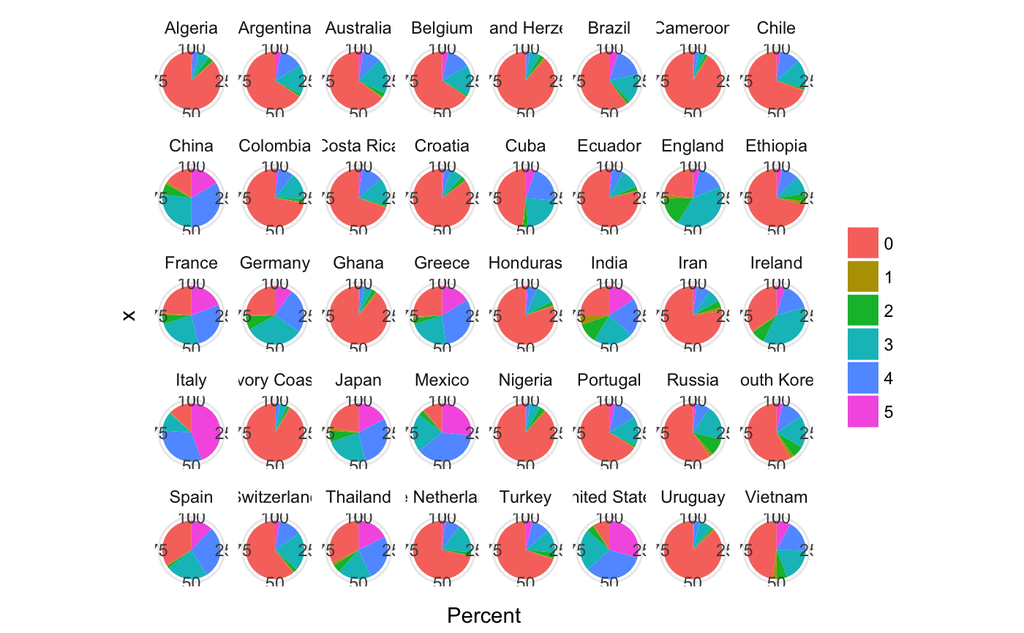

```r
percentages=food_world_cup %>%
  select(algeria:vietnam) %>%
  gather(x,y) %>%
  group_by(x,y) %>%
  summarise(n=n()) %>%
  mutate(Percent=round(n/sum(n)*100,2))
# rename countries and plot
percentages %>%
  mutate(x_2=gsub("_"," ",x)) %>%
  mutate(x_2=gsub("(^|[[:space:]])([[:alpha:]])","\\1\\U\\2",x_2,perl=TRUE)) %>%
  mutate(x_2=gsub("And","and",x_2)) %>%
  ggplot(aes(x="",y=Percent,fill=y))+
  geom_bar(width = 1,stat="identity")+
  theme_minimal()+
  coord_polar("y",start = 0)+
  facet_wrap(~x_2,ncol=8)+
  labs(fill="")
```

Imputing missing values, install package mice

```r
library(mice)
dataset_impute=mice(food_world_cup[,-c(1,2)],print=FALSE) # imputes all missing values except in columns 1,2
# replace the food world cup dataset with the imputations
food_world_cup=cbind(food_world_cup[,2,drop=FALSE],mice::complete(dataset_impute,1))
```

Transforming preference variable- perference (points awarded) is categorical but using them as factor levels make models more complex - so they are converted into numbers and transforming them by dividing through the mean of the non zero values for each country.

```r
str(food_world_cup[,8:47])
```

```
'data.frame':   1373 obs. of  40 variables:
 $ algeria               : chr  "0" "0" "3" "0" ...
 $ argentina             : chr  "3" "0" "4" "3" ...
 $ australia             : chr  "5" "3" "0" "0" ...
 $ belgium               : chr  "4" "3" "3" "3" ...
 $ bosnia_and_herzegovina: chr  "0" "0" "0" "0" ...
 $ brazil                : chr  "3" "3" "4" "0" ...
 $ cameroon              : chr  "0" "0" "5" "3" ...
 $ chile                 : chr  "4" "0" "5" "3" ...
 $ china                 : chr  "4" "2" "3" "4" ...
 $ colombia              : chr  "0" "0" "4" "2" ...
 $ costa_rica            : chr  "4" "0" "5" "4" ...
 $ croatia               : chr  "0" "0" "3" "0" ...
 $ cuba                  : chr  "0" "0" "4" "4" ...
 $ ecuador               : chr  "0" "0" "3" "0" ...
```

[output cut: 26 more lines]

```r
# convert all of these to numbers
food_world_cup[8:47]=lapply(food_world_cup[8:47],FUN = as.numeric)
countries=paste(colnames(food_world_cup)[-c(1:7)])
for (countryname in countries){
  food_world_cup[paste(countryname,"trans",sep = "_")]=food_world_cup[countryname]/mean(food_world_cup[food_world_cup[countryname]>0,countryname])
}
```

We now plot density curves to see the distributions of transformed countries

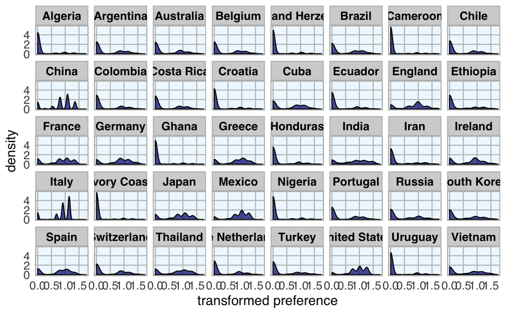

```r
food_world_cup %>%
  gather(x,y,algeria_trans:vietnam_trans) %>%
  mutate(x_2=gsub("_trans","",x)) %>%
  mutate(x_2=gsub("_"," ",x_2)) %>%
  mutate(x_2=gsub("(^|[[:space:]])([[:alpha:]])","\\1\\U\\2",x_2,perl=TRUE)) %>%
  mutate(x_2=gsub("And","and",x_2)) %>%
  ggplot(aes(y))+
  geom_density(fill="navy",alpha=0.7)+
  mytheme()+
  facet_wrap(~x_2,ncol = 8)+
  labs(x="transformed preference")
```

Next we want to see which countries are most like and whether there is a gender bias for cuisines for certain countries

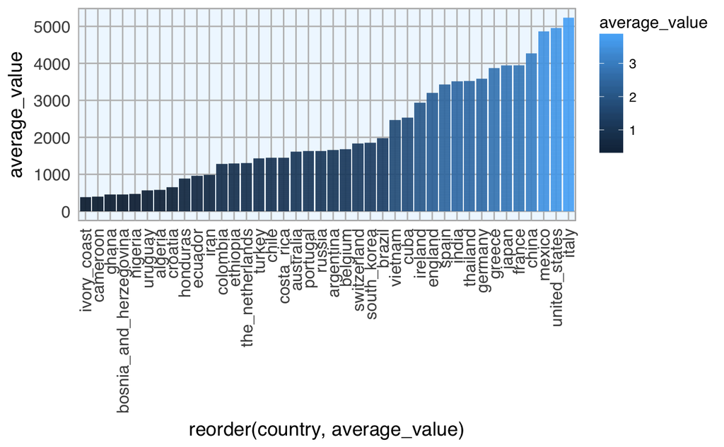

```r
food_world_cup_gather=food_world_cup %>%
  collect() %>%
  gather(country,value,algeria:vietnam)
food_world_cup_gather$country=as.factor(food_world_cup_gather$country)
food_world_cup_gather$value=as.numeric(food_world_cup_gather$value)
# most liked cuisines
food_world_cup_gather %>%
  select(country,value) %>%
  group_by(country) %>%
  mutate(average_value=mean(value)) %>%
  arrange(desc(average_value)) %>%
  ggplot(aes(x=reorder(country,average_value),y=average_value,fill=average_value))+
  geom_bar(stat="identity")+
  mytheme()+
  theme(axis.text.x = element_text(angle=90,vjust = 0.5,hjust = 1))
```

One last data manipulation before machine learning, finding the difference between the genders

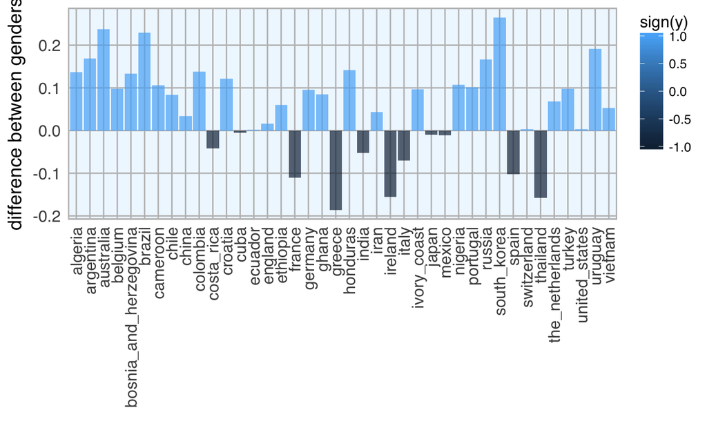

```r
food_world_cup %>%
  collect() %>%
  mutate_each_(funs(as.numeric),countries) %>% # note the mutate_each_ (- after each)
  group_by(gender) %>%
  summarise_each_(funs(mean),countries) %>%  # _ after each means to summarize by the given variable, i.e countries
  summarise_each_(funs(diff),countries) %>% # computes the diff between the two categories- genders
  gather(x,y) %>%
  ggplot(aes(x,y,fill=sign(y)))+
  geom_bar(stat="identity",alpha=0.7)+
  mytheme()+
  theme(axis.text.x = element_text(angle=90,vjust=0.5,hjust=1))+
  labs(x="",y="difference between genders")
```

```r
NA
```